# Дисперсионный анализ, часть 2

## Данные для графика при помощи `predict()`

У нас два дискретных фактора, поэтому вначале используем `expand.grid()`

```r
MyData_pengs <- expand.grid(sex = levels(pengs$sex),
                            sp = levels(pengs$sp))
MyData_pengs <- data.frame(
  MyData_pengs,
  predict(mod_treat_pengs, newdata = MyData_pengs, interval = 'confidence')
)

MyData_pengs
```

```
     sex        sp  fit  lwr  upr
1 female    Adelie 3369 3298 3440
2   male    Adelie 4043 3972 4115
3 female Chinstrap 3527 3423 3632
4   male Chinstrap 3939 3835 4043
5 female    Gentoo 4680 4600 4760
6   male    Gentoo 5485 5407 5563
```

## Задание 2

Создайте MyData вручную для модели в обычной параметризации:

- предсказанные значения
- стандартные ошибки
- верхнюю и нижнюю границы доверительных интервалов

```
     sex        sp  fit   se  lwr  upr
1 female    Adelie 3369 36.2 3296 3441
2   male    Adelie 4043 36.2 3971 4116
3 female Chinstrap 3527 53.1 3421 3633
4   male Chinstrap 3939 53.1 3833 4045
5 female    Gentoo 4680 40.6 4598 4761
6   male    Gentoo 5485 39.6 5406 5564
```

## Решение:

```r
MyData_pengs <- expand.grid(sex = levels(pengs$sex),
                            sp = levels(pengs$sp))
X_pengs <- model.matrix(~ sp * sex, data = MyData_pengs)
betas_pengs <- coef(mod_treat_pengs)
MyData_pengs$fit <- X_pengs %*% betas_pengs
MyData_pengs$se <- sqrt(diag(X_pengs %*% vcov(mod_treat_pengs) %*% t(X_pengs)))
MyData_pengs$lwr <- MyData_pengs$fit - 2 * MyData_pengs$se
MyData_pengs$upr <- MyData_pengs$fit + 2 * MyData_pengs$se
MyData_pengs
```

```
     sex        sp  fit   se  lwr  upr
1 female    Adelie 3369 36.2 3296 3441
2   male    Adelie 4043 36.2 3971 4116
3 female Chinstrap 3527 53.1 3421 3633
4   male Chinstrap 3939 53.1 3833 4045
5 female    Gentoo 4680 40.6 4598 4761
6   male    Gentoo 5485 39.6 5406 5564
```

## Альтернатива: Пост-хок по взаимодействию через `emmeans`

```r
library(emmeans)

# Предельные средние по всем комбинациям sp × sex
emm <- emmeans(mod_sum_pengs, ~ sp * sex)
emm
```

```
 sp        sex    emmean   SE  df lower.CL upper.CL
 Adelie    female   3369 36.2 327     3298     3440
 Chinstrap female   3527 53.1 327     3423     3632
 Gentoo    female   4680 40.6 327     4600     4760
 Adelie    male     4043 36.2 327     3972     4115
 Chinstrap male     3939 53.1 327     3835     4043
 Gentoo    male     5485 39.6 327     5407     5563

Confidence level used: 0.95
```

## Альтернатива: Пост-хок по взаимодействию через `emmeans`

```r
# Все попарные сравнения ячеек с поправкой Тьюки
pairs(emm, adjust = "tukey")
```

```
 contrast                          estimate   SE  df t.ratio p.value
 Adelie female - Chinstrap female      -158 64.2 327  -2.500  0.1380
 Adelie female - Gentoo female        -1311 54.4 327 -24.100 <0.0001
 Adelie female - Adelie male           -675 51.2 327 -13.200 <0.0001
 Adelie female - Chinstrap male        -570 64.2 327  -8.900 <0.0001
 Adelie female - Gentoo male          -2116 53.7 327 -39.400 <0.0001
 Chinstrap female - Gentoo female     -1153 66.8 327 -17.200 <0.0001
 Chinstrap female - Adelie male        -516 64.2 327  -8.000 <0.0001
 Chinstrap female - Chinstrap male     -412 75.0 327  -5.500 <0.0001
 Chinstrap female - Gentoo male       -1958 66.2 327 -29.600 <0.0001
 Gentoo female - Adelie male            636 54.4 327  11.700 <0.0001
 Gentoo female - Chinstrap male         741 66.8 327  11.100 <0.0001
 Gentoo female - Gentoo male           -805 56.7 327 -14.200 <0.0001
 Adelie male - Chinstrap male           105 64.2 327   1.600  0.5810
 Adelie male - Gentoo male            -1441 53.7 327 -26.900 <0.0001
 Chinstrap male - Gentoo male         -1546 66.2 327 -23.300 <0.0001

P value adjustment: tukey method for comparing a family of 6 estimates
```

## Альтернатива: Пост-хок по взаимодействию через `emmeans`

```r
# Компактные буквы (CLD): группы, не различающиеся значимо, получают одну букву
multcomp::cld(emm, adjust = "tukey", Letters = letters)
```

```
 sp        sex    emmean   SE  df lower.CL upper.CL .group
 Adelie    female   3369 36.2 327     3273     3465  a
 Chinstrap female   3527 53.1 327     3387     3668  a
 Chinstrap male     3939 53.1 327     3799     4079   b
 Adelie    male     4043 36.2 327     3948     4139   b
 Gentoo    female   4680 40.6 327     4572     4787    c
 Gentoo    male     5485 39.6 327     5380     5590     d

Confidence level used: 0.95
Conf-level adjustment: sidak method for 6 estimates
P value adjustment: tukey method for comparing a family of 6 estimates
significance level used: alpha = 0.05
NOTE: If two or more means share the same grouping symbol,
      then we cannot show them to be different.
      But we also did not show them to be the same.
```

## Задание 3

Постройте график результатов, на котором будут изображены предсказанные средние значения в зависимости от вида и пола.

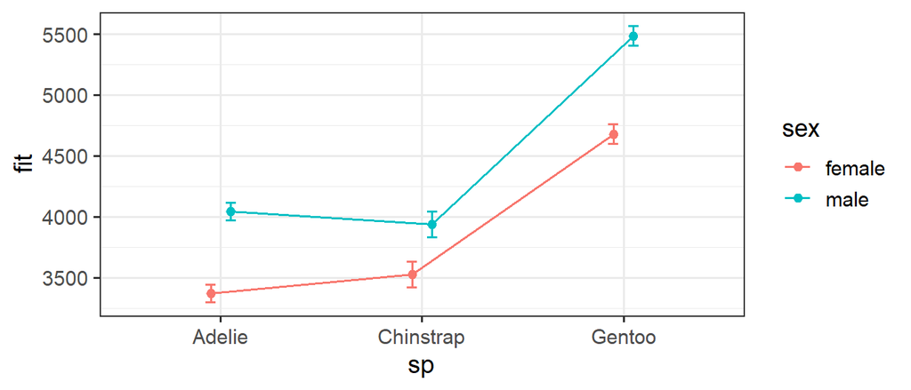

## График результатов: Линии с точками

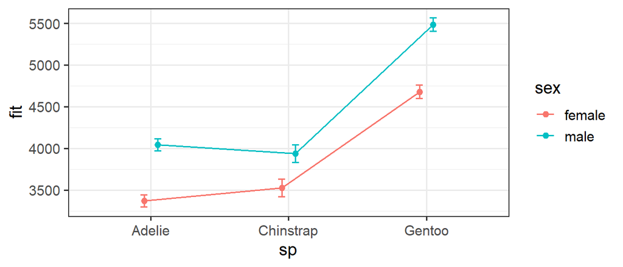

```r
pos <- position_dodge(width = 0.2)
gg_linep <- ggplot(data = MyData_pengs, aes(x = sp, y = fit,
                                            ymin = lwr, ymax = upr, colour = sex)) +
  geom_point(position = pos) +
  geom_line(aes(group = sex), position = pos) +
  geom_errorbar(position = pos, width = 0.1)
gg_linep
```

## Приводим график в приличный вид

```r
gg_final <- gg_linep + labs(x = 'Вид', y = 'Масса тела, г') +
  scale_colour_manual(name = '', labels = c('Самки', 'Самцы'),
                      values = c('#FF0091', '#0077FF'))
gg_final
```

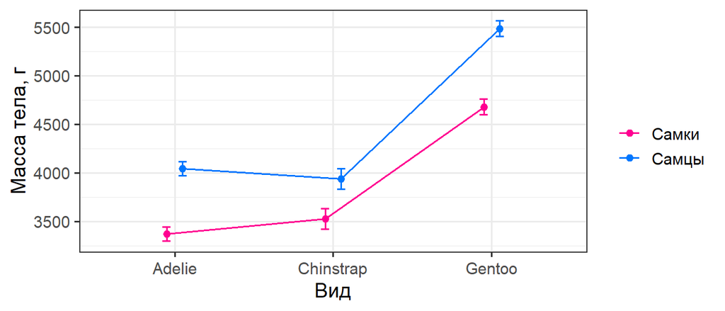

## Take home messages

- Многофакторный дисперсионный анализ позволяет оценить взаимодействие факторов. Если оно значимо, то лучше воздержаться от интерпретации их индивидуальных эффектов.
- Если численности групп равны, получаются одинаковые результаты вне зависимости от порядка тестирования значимости факторов.
- В случае, если численности групп неравны (несбалансированные данные), есть несколько способов тестирования значимости факторов (I, II, III типы сумм квадратов).

## Дополнительные ресурсы

- Quinn, Keough, 2002, pp. 221-250
- Logan, 2010, pp. 313-359
- Sokal, Rohlf, 1995, pp. 321-362
- Zar, 2010, pp. 246-266